# Ensemble Project - Term Sale Deposit

## Input variables:

### Bank Client Data:

1 - age (numeric)

2 - job : type of job (categorical: admin, blue-collar, entrepreneur, housemaid, management, retired,self-employed, services, student,technician, unemployed, unknown)

3 - marital marital status (categorical: divorced, married, single, unknown)

4 - education : education level (categorical: primary, secondary, tertiary, unknown)

5 - default: has credit in default? (categorical: no, yes)

6 - balance – balance in account (numeric)

7 - housing: has housing loan? (categorical: no,yes)

8 - loan: has personal loan? (categorical: no,yes)

### Related with the last contact of the current campaign:

9 - contact: contact communication type (categorical: cellular,telephone, unknown)

10 - day: last contact - day of the month (numeric)

11 - month: last contact month of year (categorical: jan, feb, mar, ..., nov, dec)

12 - duration: last contact duration, in seconds (numeric).

### Other attributes:

13 - campaign: number of contacts performed during this campaign and for this client (numeric, includes last contact)

15 - previous: number of contacts performed before this campaign and for this client (numeric)

16 - poutcome: outcome of the previous marketing campaign (categorical: failure,unknown,success, other)

Output variable (desired target):

17 - Target - has the client subscribed a term deposit? (binary: yes,no)

```python
#Import libraries

import numpy as np
import pandas as pd
import seaborn as sns
import matplotlib.pyplot as plt
%matplotlib inline
import scipy.stats as stats
```

```python
#Importing Data (csv file), assigning to BankData and displaying first 5 rows

BankData = pd.read_csv('bank-full.csv')
BankData.head()
```

|  | age | job | marital | education | default | balance | housing | loan | contact | day | month | duration | campaign | pdays | previous | poutcome | Target |
| --- | --- | --- | --- | --- | --- | --- | --- | --- | --- | --- | --- | --- | --- | --- | --- | --- | --- |
| 0 | 58 | management | married | tertiary | no | 2143 | yes | no | unknown | 5 | may | 261 | 1 | -1 | 0 | unknown | no |
| 1 | 44 | technician | single | secondary | no | 29 | yes | no | unknown | 5 | may | 151 | 1 | -1 | 0 | unknown | no |
| 2 | 33 | entrepreneur | married | secondary | no | 2 | yes | yes | unknown | 5 | may | 76 | 1 | -1 | 0 | unknown | no |
| 3 | 47 | blue-collar | married | unknown | no | 1506 | yes | no | unknown | 5 | may | 92 | 1 | -1 | 0 | unknown | no |
| 4 | 33 | unknown | single | unknown | no | 1 | no | no | unknown | 5 | may | 198 | 1 | -1 | 0 | unknown | no |

# Categorical variables - job, marital,education,default,housing,loan,contact,day,month,poutcome,target

# continuous variables - age,balance,day,duration,camapign,pdays,previous

## Univariate Analysis

```python
#Shape of data

BankData.shape
```

```
(45211, 17)
```

```python
# Value counts of all the category column

vc = ['job', 'marital', 'education', 'default', 'housing', 'loan','contact', 'month', 'poutcome' ]

for val in vc:
    print("Categorical Data: ",val)
    print("*****************************")
    print(BankData[val].value_counts())
    print()
```

```
Categorical Data:  job
blue-collar      9732
management       9458
technician       7597
admin.           5171
services         4154
retired          2264
self-employed    1579
entrepreneur     1487
unemployed       1303
housemaid        1240
student           938
unknown           288
Name: job, dtype: int64

Categorical Data:  marital
married     27214
single      12790
divorced     5207
Name: marital, dtype: int64

Categorical Data:  education
secondary    23202
tertiary     13301
primary       6851
unknown       1857
Name: education, dtype: int64

Categorical Data:  default
no     44396
yes      815
Name: default, dtype: int64

Categorical Data:  housing
yes    25130
no     20081
Name: housing, dtype: int64

Categorical Data:  loan
no     37967
```

[output cut: 15 more lines]

```
apr     2932
feb     2649
jan     1403
oct      738
sep      579
mar      477
dec      214
Name: month, dtype: int64

Categorical Data:  poutcome
unknown    36959
failure     4901
other       1840
success     1511
Name: poutcome, dtype: int64
```

```python
# Data Types for each column

BankData.dtypes
```

```
age           int64
job          object
marital      object
education    object
default      object
balance       int64
housing      object
loan         object
contact      object
day           int64
month        object
duration      int64
campaign      int64
pdays         int64
previous      int64
poutcome     object
Target       object
dtype: object
```

```python
BankData.describe()
```

|  | age | balance | day | duration | campaign | pdays | previous |
| --- | --- | --- | --- | --- | --- | --- | --- |
| count | 45211.000000 | 45211.000000 | 45211.000000 | 45211.000000 | 45211.000000 | 45211.000000 | 45211.000000 |
| mean | 40.936210 | 1362.272058 | 15.806419 | 258.163080 | 2.763841 | 40.197828 | 0.580323 |
| std | 10.618762 | 3044.765829 | 8.322476 | 257.527812 | 3.098021 | 100.128746 | 2.303441 |
| min | 18.000000 | -8019.000000 | 1.000000 | 0.000000 | 1.000000 | -1.000000 | 0.000000 |
| 25% | 33.000000 | 72.000000 | 8.000000 | 103.000000 | 1.000000 | -1.000000 | 0.000000 |
| 50% | 39.000000 | 448.000000 | 16.000000 | 180.000000 | 2.000000 | -1.000000 | 0.000000 |
| 75% | 48.000000 | 1428.000000 | 21.000000 | 319.000000 | 3.000000 | -1.000000 | 0.000000 |
| max | 95.000000 | 102127.000000 | 31.000000 | 4918.000000 | 63.000000 | 871.000000 | 275.000000 |

```python
BankData.describe().transpose()
```

|  | count | mean | std | min | 25% | 50% | 75% | max |
| --- | --- | --- | --- | --- | --- | --- | --- | --- |
| age | 45211.0 | 40.936210 | 10.618762 | 18.0 | 33.0 | 39.0 | 48.0 | 95.0 |
| balance | 45211.0 | 1362.272058 | 3044.765829 | -8019.0 | 72.0 | 448.0 | 1428.0 | 102127.0 |
| day | 45211.0 | 15.806419 | 8.322476 | 1.0 | 8.0 | 16.0 | 21.0 | 31.0 |
| duration | 45211.0 | 258.163080 | 257.527812 | 0.0 | 103.0 | 180.0 | 319.0 | 4918.0 |
| campaign | 45211.0 | 2.763841 | 3.098021 | 1.0 | 1.0 | 2.0 | 3.0 | 63.0 |
| pdays | 45211.0 | 40.197828 | 100.128746 | -1.0 | -1.0 | -1.0 | -1.0 | 871.0 |
| previous | 45211.0 | 0.580323 | 2.303441 | 0.0 | 0.0 | 0.0 | 0.0 | 275.0 |

```python
#Check for null values

BankData.info()
```

```
<class 'pandas.core.frame.DataFrame'>
RangeIndex: 45211 entries, 0 to 45210
Data columns (total 17 columns):
 #   Column     Non-Null Count  Dtype
---  ------     --------------  -----
 0   age        45211 non-null  int64
 1   job        45211 non-null  object
 2   marital    45211 non-null  object
 3   education  45211 non-null  object
 4   default    45211 non-null  object
 5   balance    45211 non-null  int64
 6   housing    45211 non-null  object
 7   loan       45211 non-null  object
 8   contact    45211 non-null  object
 9   day        45211 non-null  int64
 10  month      45211 non-null  object
 11  duration   45211 non-null  int64
 12  campaign   45211 non-null  int64
 13  pdays      45211 non-null  int64
 14  previous   45211 non-null  int64
 15  poutcome   45211 non-null  object
 16  Target     45211 non-null  object
dtypes: int64(7), object(10)
memory usage: 5.9+ MB
```

```python
BankData.isnull().info()
```

```
<class 'pandas.core.frame.DataFrame'>
RangeIndex: 45211 entries, 0 to 45210
Data columns (total 17 columns):
 #   Column     Non-Null Count  Dtype
---  ------     --------------  -----
 0   age        45211 non-null  bool
 1   job        45211 non-null  bool
 2   marital    45211 non-null  bool
 3   education  45211 non-null  bool
 4   default    45211 non-null  bool
 5   balance    45211 non-null  bool
 6   housing    45211 non-null  bool
 7   loan       45211 non-null  bool
 8   contact    45211 non-null  bool
 9   day        45211 non-null  bool
 10  month      45211 non-null  bool
 11  duration   45211 non-null  bool
 12  campaign   45211 non-null  bool
 13  pdays      45211 non-null  bool
 14  previous   45211 non-null  bool
 15  poutcome   45211 non-null  bool
 16  Target     45211 non-null  bool
dtypes: bool(17)
memory usage: 750.7 KB
```

```python
BankData.isna().any()
```

```
age          False
job          False
marital      False
education    False
default      False
balance      False
housing      False
loan         False
contact      False
day          False
month        False
duration     False
campaign     False
pdays        False
previous     False
poutcome     False
Target       False
dtype: bool
```

```python
# Checking for negative values in Integer Data columns

totalEntries = len(BankData) # totalEntries - number of entries (rows) in the dataset
intColumns = ['age','balance','day','duration','campaign','pdays','previous']
for col in intColumns:
    count = 0;  # count - to keep track of numer of negative entries
    print('Column = ',col)  #pinting the current column
    for i in range(0,totalEntries):
       if (BankData[col][i] < 0):
            #print(BD[temp][i])
            count = count + 1
    print('Total number of Negative entries = ', count)
```

```
Column =  age
Total number of Negative entries =  0
Column =  balance
Total number of Negative entries =  3766
Column =  day
Total number of Negative entries =  0
Column =  duration
Total number of Negative entries =  0
Column =  campaign
Total number of Negative entries =  0
Column =  pdays
Total number of Negative entries =  36954
Column =  previous
Total number of Negative entries =  0
```

# There are negative numbers for balance and pdays. Since there are 3766 negative numbers for balance, it can be assumed that this was not a mistake. Further, balance can be negative too. In the case of pdays, there are 36954 negative numbers. In this case, -1 is assigned if a person has not been contacted or contact is beyond 900 days)

## Visualization

```python
BankData.nunique()
```

```
age            77
job            12
marital         3
education       4
default         2
balance      7168
housing         2
loan            2
contact         3
day            31
month          12
duration     1573
campaign       48
pdays         559
previous       41
poutcome        4
Target          2
dtype: int64
```

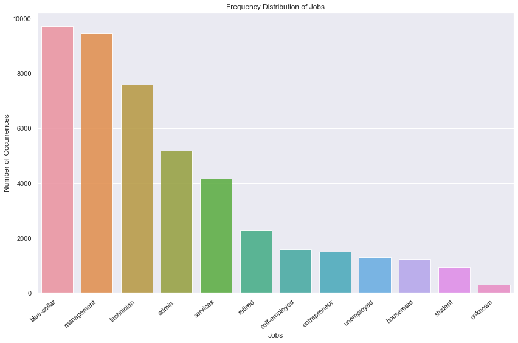

```
blue-collar      9732
management       9458
technician       7597
admin.           5171
services         4154
retired          2264
self-employed    1579
entrepreneur     1487
unemployed       1303
housemaid        1240
student           938
unknown           288
Name: job, dtype: int64
```

```python
#frequency distribution of categories on categorical variables


j_count = BankData['job'].value_counts()
plt.figure(figsize=(12,8))
plt.rcParams["xtick.labelsize"] = 10
sns.set(style="darkgrid")
ax = sns.barplot(j_count.index,j_count.values, alpha=0.9)
plt.title('Frequency Distribution of Jobs')
plt.ylabel('Number of Occurrences', fontsize=12)
plt.xlabel('Jobs', fontsize=12)
ax.set_xticklabels(ax.get_xticklabels(), rotation=40, ha="right")
plt.tight_layout()
plt.show()
BankData['job'].value_counts()
```

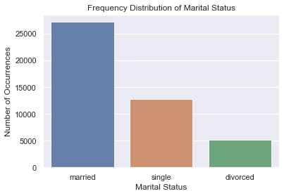

```
married     27214
single      12790
divorced     5207
Name: marital, dtype: int64
```

```python
m_count = BankData['marital'].value_counts()

mx = sns.barplot(m_count.index,m_count.values, alpha=0.9)
plt.title('Frequency Distribution of Marital Status')
plt.ylabel('Number of Occurrences', fontsize=12)
plt.xlabel('Marital Status', fontsize=12)

plt.show()
BankData['marital'].value_counts()
```

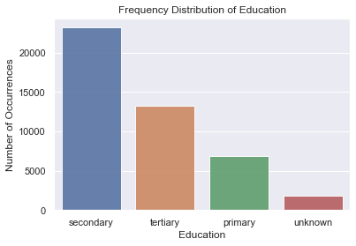

```
secondary    23202
tertiary     13301
primary       6851
unknown       1857
Name: education, dtype: int64
```

```python
e_count = BankData['education'].value_counts()
ex = sns.barplot(e_count.index,e_count.values, alpha=0.9)
plt.title('Frequency Distribution of Education')
plt.ylabel('Number of Occurrences', fontsize=12)
plt.xlabel('Education', fontsize=12)
plt.show()
BankData['education'].value_counts()
```

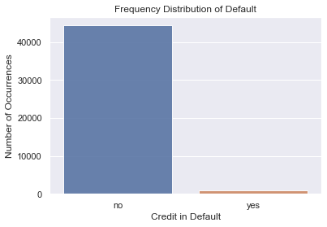

```
no     44396
yes      815
Name: default, dtype: int64
```

```python
d_count = BankData['default'].value_counts()
dx = sns.barplot(d_count.index,d_count.values, alpha=0.9)
plt.title('Frequency Distribution of Default')
plt.ylabel('Number of Occurrences', fontsize=12)
plt.xlabel('Credit in Default', fontsize=12)
# ax.set_xticklabels(ax.get_xticklabels(), rotation=40, ha="right")
# plt.tight_layout()
plt.show()
BankData['default'].value_counts()
```

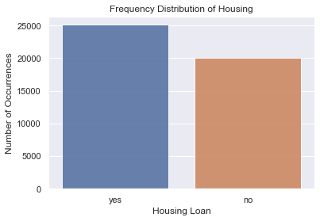

```
yes    25130
no     20081
Name: housing, dtype: int64
```

```python
h_count = BankData['housing'].value_counts()
hx = sns.barplot(h_count.index,h_count.values, alpha=0.9)
plt.title('Frequency Distribution of Housing')
plt.ylabel('Number of Occurrences', fontsize=12)
plt.xlabel('Housing Loan', fontsize=12)
plt.show()
BankData['housing'].value_counts()
```

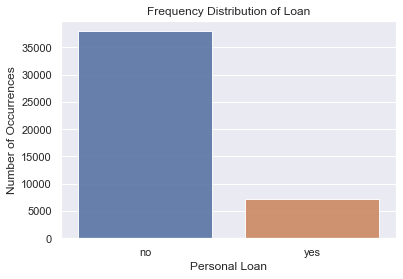

```
no     37967
yes     7244
Name: loan, dtype: int64
```

```python
l_count = BankData['loan'].value_counts()

lx = sns.barplot(l_count.index,l_count.values, alpha=0.9)
plt.title('Frequency Distribution of Loan')
plt.ylabel('Number of Occurrences', fontsize=12)
plt.xlabel('Personal Loan', fontsize=12)
plt.show()
BankData['loan'].value_counts()
```

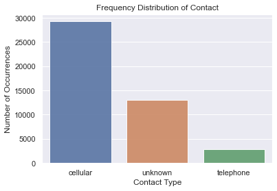

```
cellular     29285
unknown      13020
telephone     2906
Name: contact, dtype: int64
```

```python
co_count = BankData['contact'].value_counts()

cox = sns.barplot(co_count.index,co_count.values, alpha=0.9)
plt.title('Frequency Distribution of Contact')
plt.ylabel('Number of Occurrences', fontsize=12)
plt.xlabel('Contact Type', fontsize=12)

plt.show()
BankData['contact'].value_counts()
```

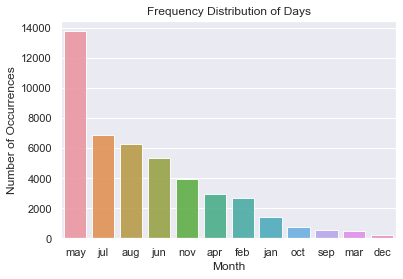

```
may    13766
jul     6895
aug     6247
jun     5341
nov     3970
apr     2932
feb     2649
jan     1403
oct      738
sep      579
mar      477
dec      214
Name: month, dtype: int64
```

```python
mo_count = BankData['month'].value_counts()

mox = sns.barplot(mo_count.index,mo_count.values, alpha=0.9)
plt.title('Frequency Distribution of Days')
plt.ylabel('Number of Occurrences', fontsize=12)
plt.xlabel('Month', fontsize=12)

plt.show()
BankData['month'].value_counts()
```

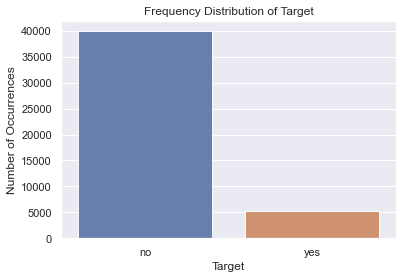

```
no     39922
yes     5289
Name: Target, dtype: int64
```

```python
T_count = BankData['Target'].value_counts()

Tx = sns.barplot(T_count.index,T_count.values, alpha=0.9)
plt.title('Frequency Distribution of Target')
plt.ylabel('Number of Occurrences', fontsize=12)
plt.xlabel('Target', fontsize=12)

plt.show()
BankData['Target'].value_counts()
```

```python
print(BankData['Target'].value_counts(normalize=True)*100)
```

```
no     88.30152
yes    11.69848
Name: Target, dtype: float64
```